# Problem Set 8

Due date: 20 November

Please upload your completed assignment to the ELMs course site (under the assignments menu). Remember to include an annotated script file for all work with R and show your math for all other problems (if applicable, or necessary). Please also upload your completed assignment to the Github repository that you have shared with us. *We should be able to run your script with no errors.*

**Total points: 30**

## Question 1

*Points: 5*

**Note**

5/5

For the following regression equation, $\hat{Y} = 8.5 + 6x + \epsilon$, the standard error for $\beta_0$ is 2.5, the standard error for $\beta_1$ is 3.5, and the sample size is 2000. Find the t-statistic, 95% confidence interval, and p-value (using a two-tailed test) for $\beta_1$.

Is $\beta_1$ statistically significant at the 0.05-level with a two-tailed test? Why or why not?

Answer:

1. The t-statistic is calculated by $t=\beta_1/SE_{\beta_1}$ which returns a value of 1.7142857.
2. For the 95% CI, it can be calculated by $\beta_1 \pm t*SE_{\beta_1}$ where the sample size $n$ is 2000 which gives a critical value roughly the same as in normal distribution. Hence, the 95% CI is [-0.86, 12.86]
3. The two-tailed p-value is 0.0866 and thus is *not* statistically significant at the 5% significance level, i.e., $\alpha=0.05$ - we have a 8.6% chance for the null hypothesis to be true which exceeds our level of tolerance. (see calculation below).

   ```r
   2 * (1 - pt(abs(1.7143), 1998))
   ```

   ```
   [1] 0.08662873
   ```

## Question 2

*Points: 5*

**Note**

5/5

Suppose you estimate an OLS regression and retrieve a $R^2$ value of 0.45. If the Total Sum of Squares (TSS) from that regression equals 4,700, what is the value for the Residual Sum of Squares (RSS)?

Answer:

Since $R^2=1-RSS/TSS$, the $RSS$ thus equals $(1-R^2)*TSS$. This returns the value of $RSS$ as 2585.

## Question 3

*Points: 5*

**Note**

5/5

Suppose you estimate a bivariate regression with a sample size of 102 and obtain a regression coefficient ($\beta_1$) of 5.0. What is the largest standard error that $\beta_1$ could have and still be statistically significant (i.e., reject the null hypothesis of no relationship) at the 0.05 level with a one-tailed test?

Answer:

For a sample size $n=102$ and a significance level of 0.05, i.e., $\alpha=0.05$, we can determine the degree of freedom $df=102-1-1=100$. Using the t-distribution table, the critical value of t-statistic is roughly $t\approx1.660$ and thus allows us to calculate the standard error by $SE_{\beta_1}=\beta_1/t$. This returns the largest standard error of 3.0120482.

## Question 4

*Points: 5*

**Note**

5/5

```r
gapminder_df <- wbstats::wb_data(c("NY.GDP.PCAP.CD", "SP.DYN.LE00.IN"),
                                 start_date = 2019, end_date = 2019) |>
  dplyr::rename(gdp_per_cap = "NY.GDP.PCAP.CD", life_exp = "SP.DYN.LE00.IN")
```

Using the `gapminder_df` data set read in above, produce a scatterplot of the variables `gdp_per_cap` and `life_exp` (with `life_exp` as the dependent variable on the y-axis). Fit a regression line to the scatterplot. Describe the relationship illustrated. Note any suspected outliers, if any (a visual inspection will suffice for this question).

**Note**

The variable `gdp_per_cap` measures each country’s GDP per capita (representing their individual wealth), and `life_exp` indicates the number of years individuals within that country born that year are expected to live (representing their health).

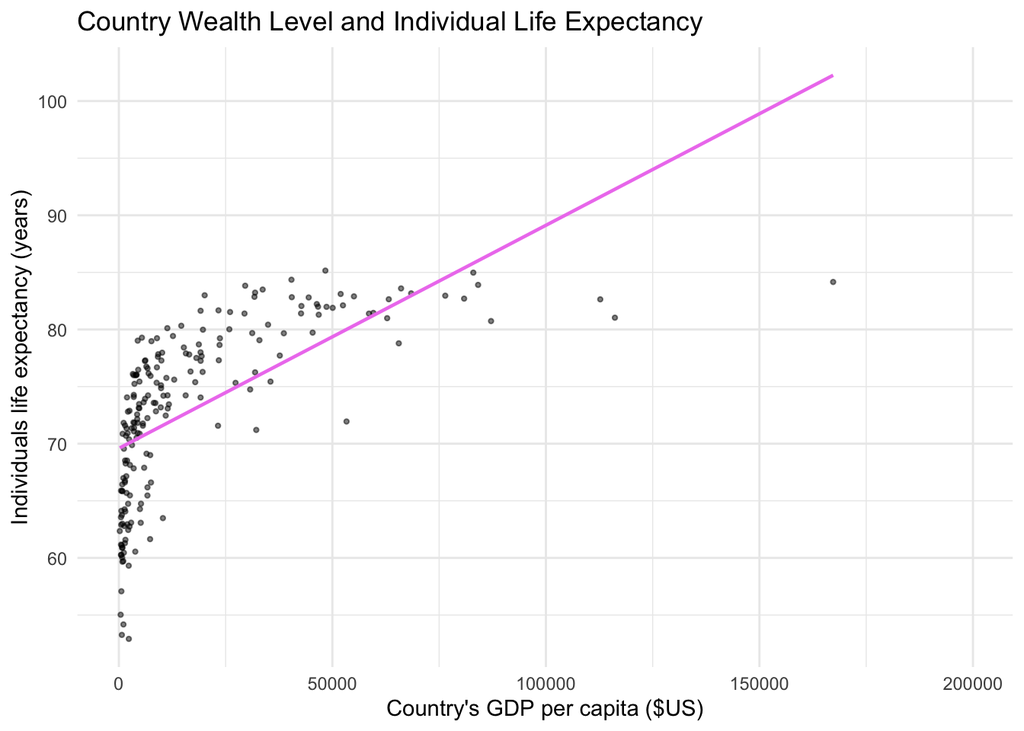

```r
library(tidyverse)
library(broom)
library(modelsummary)
library(ggdist)

ggplot(gapminder_df, aes(x = gdp_per_cap, y = life_exp)) +
  geom_point(size = 0.8, alpha = 0.5) +
  geom_smooth(method = "lm", se = F, colour = "violet", size = 0.8) +
  labs(x = "Country's GDP per capita ($US)",
       y = "Individuals life expectancy (years)",
       title = "Country Wealth Level and Individual Life Expectancy") +
  theme_minimal()
```

Answer:

The scatterplot suggests that individuals life expectancy is, *on average*, positively associated with its the country/region’s wealth level.

We seem to have a suspected outlier in the rightest quarter of the plot which refers to *Liechtenstein* - this tiny European state has a per capita GDP of $167,259 and a life expectancy of 84.16.

## Question 5

*Points: 10*

**Note**

9/10

**Note**

You should only fit a linear model when the relationship is linear. Should convert GDP per capita to its logged form.

Estimate a bivariate regression with `life_exp` as the dependent variable and `gdp_per_cap` as the independent variable and report the results in a professionally formatted table. In as much detail as possible, describe (and interpret) the regression results.

```r
m <- lm(life_exp ~ gdp_per_cap, data = gapminder_df)
summary(m)
```

```
Call:
lm(formula = life_exp ~ gdp_per_cap, data = gapminder_df)

Residuals:
    Min      1Q  Median      3Q     Max
-18.099  -3.849   1.358   4.109   9.480

Coefficients:
             Estimate Std. Error t value Pr(>|t|)
(Intercept) 6.959e+01  5.026e-01  138.46   <2e-16 ***
gdp_per_cap 1.953e-04  1.674e-05   11.67   <2e-16 ***
---
Signif. codes:  0 '***' 0.001 '**' 0.01 '*' 0.05 '.' 0.1 ' ' 1

Residual standard error: 5.795 on 200 degrees of freedom
  (15 observations deleted due to missingness)
Multiple R-squared:  0.405, Adjusted R-squared:  0.402
F-statistic: 136.1 on 1 and 200 DF,  p-value: < 2.2e-16
```

```r
modelsummary(m,
             coef_rename = c("gdp_per_cap" = "Wealth level"),
             statistic = c("conf.int", "p.value"))
```

|  | (1) |
| --- | --- |
| (Intercept) | 69.591 |
|  | [68.600, 70.583] |
|  | (<0.001) |
| Wealth level | 0.000 |
|  | [0.000, 0.000] |
|  | (<0.001) |
| Num.Obs. | 202 |
| R2 | 0.405 |
| R2 Adj. | 0.402 |
| AIC | 1287.0 |
| BIC | 1297.0 |
| Log.Lik. | −640.521 |
| F | 136.130 |
| RMSE | 5.77 |

Answer:

The regression results suggest that

1. as a country/region’s per capita GDP goes up by 1 USD, its citizens’ life expectancy increases by 0.0001953 years (i.e., $r=1.953*10^{-4}$), *on average*. Or alternatively, when per capita GDP goes up by 10,000 USD, life expectancy increases by 1.953 years, *on average*.
2. the estimated *average* life expectancy for a zero-income country/region is roughly 69.591 years (i.e., $intercept=6.959*10$) while this does not make too much sense as no country/region has a per capita GDP of 0 USD.
3. there is strong statistical evidence indicating that individuals’ life expectancy is, *on average*, positively associated with the country/region’s wealth level (i.e., $p<0.001$), though the coefficient - the effect of one unit change in the independent variable on the dependent variable - is tiny as discussed earlier.

Additionally, a visual inspection on the scatterplot implies this could be a non-linearity between these two variables.